# General Vector Spaces

- The language of linear systems of equations involved the use of concepts from the theory of general vector spaces - so we need to consider these.
- These extend 'vectors' beyond the familiar vectors in $R^n$ - but keep in mind that vectors in $R^n$ will remain our focus.
- Vector spaces allows us to generalise results across diverse area of mathematics such as: probability; calculus; signal processing etc.

## Definition: Real Vector Spaces

Let $V$ be a non-empty set of objects called vectors on which two operations called addition and multiplication by a scalar are defined.

That is: if $u$ and $w$ are two objects in $V$, we have defined a rule for $u+w$ and $ku$ where $k$ is a scalar and this holds for all objects in $V$ and all scalars $k$. [NB: we will assume real scalars $k$.]

If the following axioms are satisfied by all objects in $V$ and for all real scalars $k$, then $V$ is a **real vector space** and the objects in $V$ are called vectors.

Vector Space Axioms

| 1 | $\mbox{If } u, w, z \in V,\mbox{ then } u+w,\ u+z,\ w+z,\ u+w+z \ \in V $ | **[closure under addition]** |
| --- | --- | --- |
| 1.1 | $u+w=w+u$ | [commutative] |
| 1.2 | $u+(w+z) = (u+w)+z$ | [associative] |
| 1.3 | $u+\vec{0}=u$ | [nature of the zero vector] |
| 1.4 | $u+(-u)=\vec{0}$ | [$-u$ is the additive inverse of $u$] |
| 2 | $\mbox{Let } k, m \in \mathbb{R}.\mbox{ If } u \in V, \mbox{ then } ku, mu \in V$ | **[Closure under scalar multiplication]** |
| 2.1 | $k(u+w)=ku+kw$ | [distributive] |
| 2.2 | $(k+m)u=ku+mu$ | [distributive] |
| 2.3 | $k(mu)=(km)u$ | [associative] |
| 2.4 | $1u = u$ | [preservation of scale] |

To establish if a set $V$ is a vector space we need to check all 10 axioms. Start with checking 1 and 2 and then check the rest. This can be (at times) difficult/tedious.

**Examples: Vector Spaces**

1. $R^3$, i.e. the set of all vectors in $R^3$
2. $R^n$
3. Let $V$ be the set of all $2\times 2$ matrices with real entries.
4. Let $V$ be the set of all polynomials with real coefficients and degree $\leq 2$.

**Examples: Non Vector Spaces**

1. Let $V$ be the set of all polynomials with real coefficients and degree $= 2$.
2. Let $V=\left\{\begin{bmatrix} x \\ 1 \end{bmatrix}, \ x\in\mathbb{R}\right\}$   [what is the geometry of $V$?]
3. The set $V$ of all rational numbers with the usual definition of addition and scalar multiplication.

## Further Properties of Vector Spaces

There can be some rather strange vector spaces defined.

Example: Let $V$ be a vector space defined with vectors that are real positive numbers and with the operations of addition and scalar multiplication as:  
$u+v = uv$  
$ku = u^k$

Verify this is a vector space? [Hint: what is $\vec{0}$ and what is $-u$]

The existence of such strange vector spaces leads us to prove what otherwise look like very obvious properties of vector spaces.

**Theorem 4.1.1. [A&R]** Let $u$ be a vector in a vector space $V$.  
(a) $0u=\vec{0}$  
(b) $k\vec{0}=\vec{0}$  
(c) $(-1)u=-u$  
(d) If $ku=\vec{0}$ then either $k=0$ and/or $u=\vec{0}$

## Subspaces

Let $S$ be a subset of a vector space $V$ with the same definition of addition and scalar multiplication. $S$ may be a subspace of $V$ if it has certain characteristics that make it a vector space in its own right, i.e.

| 1 | $\mbox{If } u, w, z \in S,\mbox{ then } u+w,\ u+z,\ w+z,\ u+w+z \ \in S $ | **[closure under addition]** |
| --- | --- | --- |
| 2 | $\mbox{Let } k, m \in \mathbb{R}.\mbox{ If } u \in S, \mbox{ then } ku, mu \in S$ | **[Closure under scalar multiplication]** |
| 3 | $S \mbox{ is non-empty}$ | NB. this is often implicitly assumed by authors |

The other axioms for a vector space are inherited from $V$.

**Examples of subpaces**

1. A line through the origin in $R^2$ or $R^3$.
2. A plane through the origin in $R^3$.
3. The set of all $2\times 2$ matrices with real entries from the vector space of all $m\times n$ matrices with real entries.

**Examples of non-subpaces**

1. A line not through the origin in $R^2$ or $R^n$.
2. Let $V=\left\{\begin{bmatrix} x \\ y \end{bmatrix}, \ x \geq 0, y \geq 0\right\}$   [what is the geometry of $V$?]
3. The set of all $2\times 2$ invertible matrices with real entries from the vector space of all $m\times n$ matrices with real entries.

## Intersection of Subspaces

**Theorem 4.2.2** [A&R]  
The intersection of two (or more) subspaces of the vector space $V$, is itself a subspace of $V$.

So, if $S$ and $T$ are two subspaces of $V$, the $Q=S\cap T$ is also a subspace of $V$.

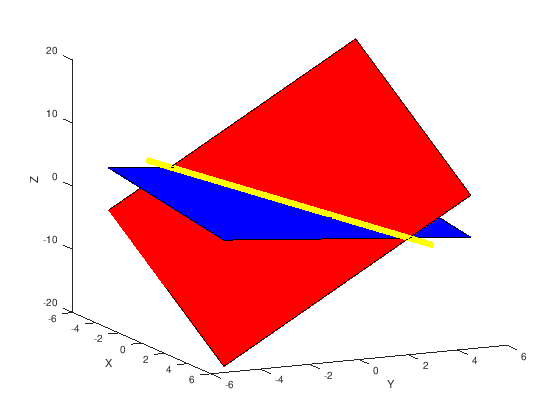

```matlab
graphics_toolkit ("fltk");
 set(gcf,'Visible','on')

  ## plot p1
 x=[-5 5 5 -5]';
 y=[-5 -5 5 5]';
 z=[-10/3 -60/3 10/3 60/3]';
 patch(x,y,z,'red');
 xlabel('X');
 ylabel('Y');
 zlabel('Z');
 view(-295,15)
 hold;

 ## Plot p2
 x=[-5 5 5 -5]';
 y=[-5 -5 5 5]';
 z=[10/3 0 -10/3 0]';
 patch(x,y,z,'blue');


 ## plot the intersection
 line([-6 6],[-3 3],[3 -3],'linewidth',5,'color','yellow');
```

# Subspaces spanned by vectors

Let $S=\{v_1, v_2, \ldots, v_k\}$ be a non-empty set of vectors in a vector space $V$.

We define a linear combination of these vectors as:

$r_1v_1+r_2v_2+\ldots+r_kv_k$ where $r_i\in \mathbb{R}$.

The set of all linear combinations of such vectors is referred to as a **span** of $S$

$$ span(S) = \left\{r_1v_1+r_2v_2+\ldots+r_kv_k \quad | \quad r_i\in \mathbb{R}\right\}$$

**Theorem 4.2.3** [A&R]  
(a) $Span(S)$ is a subspace of $V$.  
(b) $Span(S)$ is the 'smallest' subspace of $V$ that contains all the vectors in $S$ in the sense that any other subspace that contains those vectors contains $Span(S)$.

Example: Consider the vectors $v_1=\begin{bmatrix} 1 \\ 2 \\ 3 \end{bmatrix}$ and $v_2=\begin{bmatrix} 1 \\ 2 \\ -1 \end{bmatrix}$. The set $\{v_1, v_2 \}$ is called the generating or spanning set for $span(S)$. What is the geometry of $Span(S)$?

```
v1 =

   1
   2
   3

v2 =

   1
   2
  -1
```

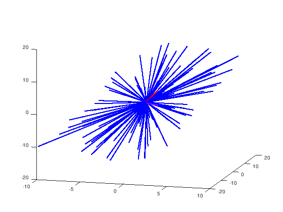

```matlab
graphics_toolkit ("fltk");
set(gcf,'Visible','on')

v1=[1;2;3]
v2=[1;2;-1]
rand("seed",1234567)
n=100;
r=-5*ones(n,2)+10*rand(n,2);
rspanV=ones(3,n)*0;
for i=1:n
    rspanV(:,i)=r(i,1)*v1+r(i,2)*v2;
    line([0 rspanV(1,i)],[0 rspanV(2,i)],[0 rspanV(3,i)],'linewidth',1,'color','blue');
    hold;
    view(-345,15)
endfor
line([0 v1(1)],[0 v1(2)],[0 v1(3)],'linewidth',3,'color','red');
line([0 v2(1)],[0 v2(2)],[0 v2(3)],'linewidth',3,'color','magenta');
```

Example: Describe the subspace spanned by the generating set:

$$\left\{ v_1=\begin{bmatrix} 1 \\ 2 \\ 3 \end{bmatrix}, \quad v_2=\begin{bmatrix} -1 \\ -2 \\ -3 \end{bmatrix}, \quad v_3=\begin{bmatrix} 3 \\ 6 \\ 9 \end{bmatrix}\right\} $$

## Important Case: Standard Unit Vectors in $R^n$

$R^1 = \left\{\quad [1] \quad\right\}$

$R^2 = \left\{\quad \begin{bmatrix} 1 \\ 0 \end{bmatrix}, \begin{bmatrix} 0 \\ 1 \end{bmatrix}\quad\right\}$

$R^3 = \left\{\quad \begin{bmatrix} 1 \\ 0 \\ 0\end{bmatrix}, \begin{bmatrix} 0 \\ 1 \\0 \end{bmatrix}, \begin{bmatrix} 0 \\ 0 \\1 \end{bmatrix}\quad \right\}$

$R^4 = \left\{\quad \begin{bmatrix} 1\\ 0\\ 0 \\ 0 \end{bmatrix}, \begin{bmatrix} 0\\ 1\\ 0 \\ 0 \end{bmatrix}, \begin{bmatrix} 0\\ 0\\ 1 \\ 0 \end{bmatrix}, \begin{bmatrix} 0\\ 0\\ 0 \\ 1 \end{bmatrix}\quad \right\}$

$R^n \quad \ldots$

Clearly these will span each space.

## Nullspace of a matrix

Find a set of vectors in $R^4$ that spans the solution space of the following homogeneous system:

$$ \begin{align*} \ x_1 + \ x_2+ 3x_3 + \ x_4 &= 0\\ 2x_1 + 3x_2+ \ x_3 +\ x_4 &= 0\\ \ x_1 \quad\quad + 8x_3 +2x_4 &= 0 \end{align*} $$

This is a subspace of $R^4$ as is called the **nullspace** of the coefficient matrix of the system.

**Theorem 4.2.4** [A&R] The solution space of a homogeneous linear system $Ax=0$ in $n$ unknowns is a subspace of $R^n$ and is called the nullspace of the matrix $A$.

**Examples**  
Determine and describe the nullspace of the following coefficient matrices.

(a) $\quad \begin{bmatrix} 1 & -2 & 3 \\ 2 & -4 & 6 \\ 3 & -6 & 9\end{bmatrix} \qquad$ (b) $\quad \begin{bmatrix} 1 & -2 & 3 \\ -3& 7 & -8\\ -2& 4 &-6\end{bmatrix}\qquad$

(c) $\quad \begin{bmatrix} 1 & -2 & 3 \\ -3& 7 & -8\\ 4& 1 &2\end{bmatrix}\qquad$ (d) $\quad \begin{bmatrix} 0 & 0 & 0 \\ 0& 0 & 0\\ 0& 0 &0\end{bmatrix}$

**Some remarks**

- The solution space for for a consistent non-homogeneous systems is not a subspace - can you see why?
- If the nullspace of the coefficient matrix ($A$) contains more than $\vec{0}$, then the corresponding consistent non-homogeneous system $Ax=b$ will have an infinite number of solutions.